# PS2

## Problem 1

1. Version 1 of the modified random walk function is implemented below:

```r
# rm(list=ls())

# loop
random_walk1 <- function(n) {
  probs <- runif(n)

  # start at 0
  position <- 0

  for (i in 1:n) {
    # move +1 or -1 with 50/50 probability
    if (probs[i] < 0.5) {
      # if +1 is chosen, 5% of the time (0.05 * 0.5) move +10
      if (probs[i] < 0.025) {
        position <- position + 10
      } else {
        position <- position + 1
      }
    } else {
      # if -1 is chosen, 20% of the time (0.20 * 0.5) move -3
      if (probs[i] > 0.9) {
        position <- position - 3
      } else {
        position <- position - 1
      }
    }
  }

  return(position)
}
```

Version 2 of the modified random walk function is implemented below:

```r
# vectorized
random_walk2 <- function(n) {
  probs <- runif(n)

  steps <- rep(1, times=n)
  steps[probs < 0.025] <- 10
  steps[probs > 0.5] <- -1
  steps[probs > 0.9] <- -3

  return(sum(steps))
}
```

Version 3 of the modified random walk function is implemented below:

```r
# apply
random_walk3 <- function(n) {
  probs <- runif(n)

  steps <- sapply(1:n, function(i) {
    if (probs[i] < 0.5) {
      if (probs[i] < 0.025) {
        return(10)
      } else {
        return(1)
      }
    } else {
      if (probs[i] > 0.9) {
       return(-3)
      } else {
        return(-1)
      }
    }
  })

  return(sum(steps))
}
```

Here, I test whether the functions work:

```r
c(random_walk1(10),
  random_walk2(10),
  random_walk3(10),
  random_walk1(1000),
  random_walk2(1000),
  random_walk3(1000))
```

```
[1]  0 -2  4 83 71 47
```

2. For this section, I modify the functions to control the randomization by setting the seed to 1.

```r
non_random_walk1 <- function(n) {

  # remove randomization and generate probabilities
  set.seed(1)
  probs <- runif(n)

  # start at 0
  position <- 0

  for (i in 1:n) {
    # move +1 or -1 with 50/50 probability
    if (probs[i] < 0.5) {
      # if +1 is chosen, 5% of the time (0.05 * 0.5) move +10
      if (probs[i] < 0.025) {
        position <- position + 10
      } else {
        position <- position + 1
      }
    } else {
      # if -1 is chosen, 20% of the time (0.20 * 0.5) move -3
      if (probs[i] > 0.9) {
        position <- position - 3
      } else {
        position <- position - 1
      }
    }
  }

  return(position)
}

non_random_walk2 <- function(n) {

  # remove randomization and generate probabilities
  set.seed(1)
  probs <- runif(n)

  steps <- rep(1, times=n)
  steps[probs < 0.025] <- 10
  steps[probs > 0.5] <- -1
  steps[probs > 0.9] <- -3

  return(sum(steps))
}

non_random_walk3 <- function(n) {

  # remove randomization and generate probabilities
  set.seed(1)
  probs <- runif(n)

  steps <- sapply(1:n, function(i) {
    if (probs[i] < 0.5) {
      if (probs[i] < 0.025) {
        return(10)
      } else {
        return(1)
      }
    } else {
      if (probs[i] > 0.9) {
       return(-3)
      } else {
        return(-1)
      }
    }
  })

  return(sum(steps))
}
```

By running the functions for n=10 and n=1000, I get the same results for all 3 functions.

```r
c(non_random_walk1(10),
  non_random_walk2(10),
  non_random_walk3(10),
  non_random_walk1(1000),
  non_random_walk2(1000),
  non_random_walk3(1000))
```

```
[1] -6 -6 -6  0  0  0
```

```r
# install.packages("microbenchmark")
library(microbenchmark)
microbenchmark(random_walk1(1000), random_walk2(1000), random_walk3(1000))
```

```
Unit: microseconds
               expr   min     lq    mean median     uq    max neval
 random_walk1(1000)  65.7  69.25  83.120  76.05  89.80  176.0   100
 random_walk2(1000)  30.9  34.85  45.945  40.05  47.20  160.1   100
 random_walk3(1000) 715.8 756.10 886.558 803.25 956.95 2599.6   100
```

```r
microbenchmark(random_walk1(100000), random_walk2(100000), random_walk3(100000))
```

```
Unit: milliseconds
                expr     min       lq       mean   median        uq      max
 random_walk1(1e+05)  6.5172  6.71395   7.429456   6.8631   7.36890  13.4476
 random_walk2(1e+05)  2.7790  3.03295   3.621592   3.3573   3.65725   8.3936
 random_walk3(1e+05) 78.8164 94.52300 110.518388 106.1855 117.36330 197.0993
 neval
   100
   100
   100
```

From the microbenchmark, the second version (the vectorized version) is the fastest, followed by the loop function, and the slowest is the apply function. This is consistent between low input and large input.

4. For this example, I will use the vectorized random walk function to reduce runtime. As seen from part (b), each function can produce the same result while controlling for randomization, so the vectorized function will not return a different result from the other functions.

```r
ns <- c(10, 100, 1000)

estimate_random_walk <- function(n, reps = 10000) {
  return(replicate(reps, random_walk2(n)))
}

position_probs <- vector(length = length(ns))

for (i in seq_along(ns)) {
  random_walks <- estimate_random_walk(ns[i])
  position_probs[i] <- mean(random_walks == 0)
}

position_probs
```

```
[1] 0.1291 0.0186 0.0060
```

The probability the random walk ends at 0 becomes closer to 0% as the number of steps increase. I think this is because, at higher step counts, it is more likely that there is at least one occurrence of taking +10 or -3 steps, and it is less likely that there is an equal number of +1 or -1 to reconcile it back to a position of zero. From the Monte Carlo simulation above, we see that the probability decreases from 13% at 10 steps to 1.9% at 100 steps to 0.6% at 1000 steps.

## Problem 2

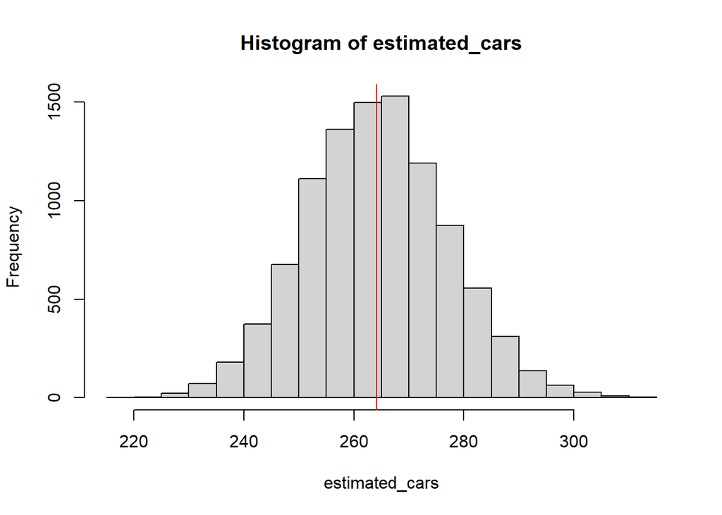

```r
estimate_cars <- function() {
  num_cars <- rep(0, times = 24)

  # midnight to 7am
  num_cars[1:8] <- rpois(length(num_cars[1:8]), lambda=1)

  # 9am to 4pm
  num_cars[10:18] <- rpois(length(num_cars[10:18]), lambda=8)

  # 6pm to 11pm
  num_cars[19:24] <- rpois(length(num_cars[19:24]), lambda=12)

  # rush hours
  num_cars[c(9,18)] <- rnorm(length(num_cars[c(9,18)]), mean = 60, sd = sqrt(12))

  return(sum(num_cars))
}

# monte carlo
reps <- 10000
estimated_cars <- replicate(reps, estimate_cars())
hist(estimated_cars)
abline(v=mean(estimated_cars), col='red')
```

```r
mean(estimated_cars)
```

```
[1] 264.1533
```

The mean is about 264 cars per day.

## Problem 3

```r
youtube <- read.csv('https://raw.githubusercontent.com/rfordatascience/tidytuesday/master/data/2021/2021-03-02/youtube.csv')
```

```r
dim(youtube)
```

```
[1] 247  25
```

```r
colnames(youtube)
```

```
 [1] "year"                      "brand"
 [3] "superbowl_ads_dot_com_url" "youtube_url"
 [5] "funny"                     "show_product_quickly"
 [7] "patriotic"                 "celebrity"
 [9] "danger"                    "animals"
[11] "use_sex"                   "id"
[13] "kind"                      "etag"
[15] "view_count"                "like_count"
[17] "dislike_count"             "favorite_count"
[19] "comment_count"             "published_at"
[21] "title"                     "description"
[23] "thumbnail"                 "channel_title"
[25] "category_id"
```

Before removing the identifying columns, the dimensions are 247 rows and 25 columns. For this section, I will choose to remove brand, superbowl_ads_dot_com_url, youtube_url, id, etag, published_at, title, description, and channel_title.

```r
youtube_new <- youtube[, -c(2, 3, 4, 12, 14, 20, 21, 22, 23, 24)]
colnames(youtube_new)
```

```
 [1] "year"                 "funny"                "show_product_quickly"
 [4] "patriotic"            "celebrity"            "danger"
 [7] "animals"              "use_sex"              "kind"
[10] "view_count"           "like_count"           "dislike_count"
[13] "favorite_count"       "comment_count"        "category_id"
```

```r
dim(youtube_new)
```

```
[1] 247  15
```

After removing the columns, the dimensions are 247 rows and 15 columns.

2. I start by making a numerical summary for these variables. From the numerical summary, we can see NA values, so I cleaned the NA values.

```r
summary(youtube_new[, 10:14])
```

```
   view_count          like_count     dislike_count     favorite_count
 Min.   :       10   Min.   :     0   Min.   :    0.0   Min.   :0
 1st Qu.:     6431   1st Qu.:    19   1st Qu.:    1.0   1st Qu.:0
 Median :    41379   Median :   130   Median :    7.0   Median :0
 Mean   :  1407556   Mean   :  4146   Mean   :  833.5   Mean   :0
 3rd Qu.:   170016   3rd Qu.:   527   3rd Qu.:   24.0   3rd Qu.:0
 Max.   :176373378   Max.   :275362   Max.   :92990.0   Max.   :0
 NA's   :16          NA's   :22       NA's   :22        NA's   :16
 comment_count
 Min.   :   0.00
 1st Qu.:   1.00
 Median :  10.00
 Mean   : 188.64
 3rd Qu.:  50.75
 Max.   :9190.00
 NA's   :25
```

```r
youtube_clean <- na.omit(youtube_new)
summary(youtube_clean[, 10:14])
```

```
   view_count          like_count       dislike_count     favorite_count
 Min.   :       10   Min.   :     0.0   Min.   :    0.0   Min.   :0
 1st Qu.:     6577   1st Qu.:    18.5   1st Qu.:    1.0   1st Qu.:0
 Median :    41828   Median :   130.0   Median :    7.0   Median :0
 Mean   :  1476249   Mean   :  4237.4   Mean   :  854.5   Mean   :0
 3rd Qu.:   176014   3rd Qu.:   480.5   3rd Qu.:   24.0   3rd Qu.:0
 Max.   :176373378   Max.   :275362.0   Max.   :92990.0   Max.   :0
 comment_count
 Min.   :   0.0
 1st Qu.:   1.0
 Median :  11.0
 Mean   : 191.2
 3rd Qu.:  51.5
 Max.   :9190.0
```

Next, I look at the histograms of the predictors to see their distribution.

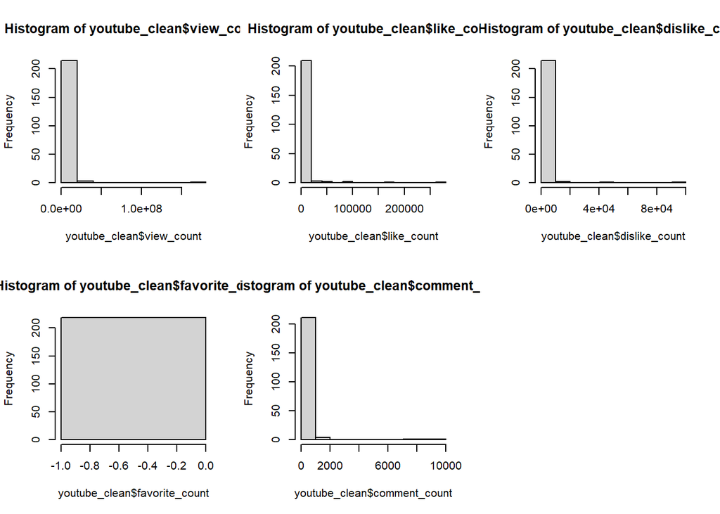

```r
par(mfrow=c(2,3))
hist(youtube_clean$view_count, breaks=12)
hist(youtube_clean$like_count, breaks=12)
hist(youtube_clean$dislike_count, breaks=12)
hist(youtube_clean$favorite_count, breaks=12)
hist(youtube_clean$comment_count, breaks=12)
```

From both the numerical and graphical summaries above, I concluded that:

- View, Like, Dislike, Comment counts: These variables are appropriate to use, however, due to their right skew, they may require a log transformation
- Favorite counts: This variable is not appropriate to use as it is the constant zero.

Hence, in this section, I carry out the log transformation. However, due to the minimum of zero as shown in the numerical summary (view count’s minimum is 10, but I wanted to keep it consistent and, truthfully, it just looked ugly doing only one log and the rest log1p, so please bear with me), I chose to use the log1p() function which computes log(1+x) to avoid errors with a log transformation on zero.

```r
youtube_clean$log_views    <- log1p(youtube_clean$view_count)
youtube_clean$log_likes    <- log1p(youtube_clean$like_count)
youtube_clean$log_dislikes <- log1p(youtube_clean$dislike_count)
youtube_clean$log_comments <- log1p(youtube_clean$comment_count)
```

Here are the histograms of the transformed variables. The log1p of dislikes and comments both still look slightly skewed, but definitely less skewed than before the transformation.

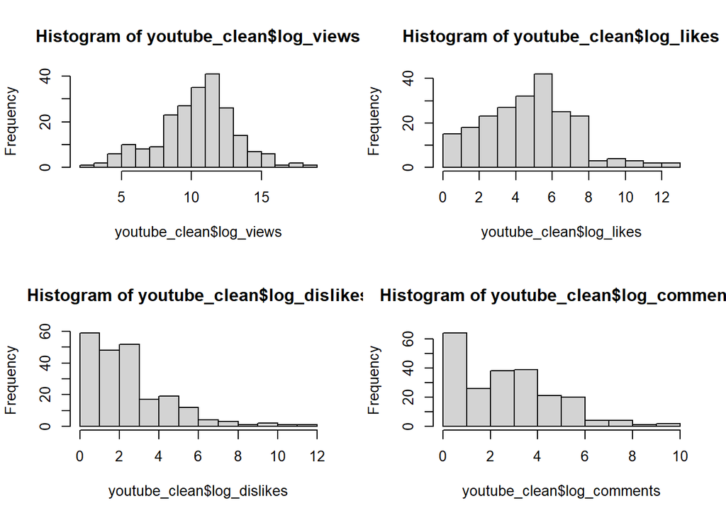

```r
par(mfrow=c(2,2))
hist(youtube_clean$log_views, breaks=12)
hist(youtube_clean$log_likes, breaks=12)
hist(youtube_clean$log_dislikes, breaks=12)
hist(youtube_clean$log_comments, breaks=12)
```

3. Next, I fit the models for the variables I decided were appropriate and transformed, which are the models for log1p(view count), log1p(like count), log1p(dislike count), and log1p(comment count). From the summaries seen later, “year” is shown to be a continuous variable, so I did not have to control for year to be a continuous variable.

```r
predictors <- c("funny", "show_product_quickly", "patriotic",
                "celebrity", "danger", "animals", "use_sex", "year")

model_views <- lm(log_views ~ ., data = youtube_clean[, c("log_views", predictors)])
model_likes <- lm(log_likes ~ ., data = youtube_clean[, c("log_likes", predictors)])
model_dislikes <- lm(log_dislikes ~ ., data = youtube_clean[, c("log_dislikes", predictors)])
model_comments <- lm(log_comments ~ ., data = youtube_clean[, c("log_comments", predictors)])
```

```r
summary(model_views)
```

```
Call:
lm(formula = log_views ~ ., data = youtube_clean[, c("log_views",
    predictors)])

Residuals:
    Min      1Q  Median      3Q     Max
-8.2357 -1.6062  0.2332  1.6347  8.5156

Coefficients:
                          Estimate Std. Error t value Pr(>|t|)
(Intercept)              -40.95957   71.99742  -0.569   0.5700
funnyTRUE                  0.75181    0.47416   1.586   0.1143
show_product_quicklyTRUE   0.26142    0.41192   0.635   0.5264
patrioticTRUE              0.97186    0.56177   1.730   0.0851 .
celebrityTRUE              0.18693    0.43423   0.430   0.6673
dangerTRUE                 0.61824    0.42558   1.453   0.1478
animalsTRUE               -0.05894    0.40193  -0.147   0.8836
use_sexTRUE               -0.37680    0.45396  -0.830   0.4075
year                       0.02506    0.03580   0.700   0.4847
---
Signif. codes:  0 '***' 0.001 '**' 0.01 '*' 0.05 '.' 0.1 ' ' 1

Residual standard error: 2.77 on 210 degrees of freedom
Multiple R-squared:  0.03866,   Adjusted R-squared:  0.002034
F-statistic: 1.056 on 8 and 210 DF,  p-value: 0.3957
```

Firstly, the model that predicts the log1p of view counts. This model performed rather poorly, with an R-squared of only 0.03866. None of the predictors were deemed to be statistically significant, as none of their p-values are below 0.05. I would say that this may be because view counts is largely due to luck, on whether or not the ad goes viral or not.

```r
summary(model_likes)
```

```
Call:
lm(formula = log_likes ~ ., data = youtube_clean[, c("log_likes",
    predictors)])

Residuals:
    Min      1Q  Median      3Q     Max
-5.3142 -1.6615  0.0629  1.5222  7.7576

Coefficients:
                           Estimate Std. Error t value Pr(>|t|)
(Intercept)              -146.83814   64.04727  -2.293   0.0229 *
funnyTRUE                   0.53109    0.42180   1.259   0.2094
show_product_quicklyTRUE    0.24669    0.36643   0.673   0.5016
patrioticTRUE               0.83252    0.49974   1.666   0.0972 .
celebrityTRUE               0.46322    0.38628   1.199   0.2318
dangerTRUE                  0.61730    0.37858   1.631   0.1045
animalsTRUE                 0.01964    0.35755   0.055   0.9563
use_sexTRUE                -0.42519    0.40383  -1.053   0.2936
year                        0.07496    0.03185   2.354   0.0195 *
---
Signif. codes:  0 '***' 0.001 '**' 0.01 '*' 0.05 '.' 0.1 ' ' 1

Residual standard error: 2.464 on 210 degrees of freedom
Multiple R-squared:  0.07503,   Adjusted R-squared:  0.03979
F-statistic: 2.129 on 8 and 210 DF,  p-value: 0.03444
```

Secondly, the model that predicts log1p of like counts. This model also performed poorly with an R-squared of 0.07503. The predictor “year” has a p-value of 0.0195 < 0.05, which indicates that it is statistically significant. The direction of its estimated coefficient is positive, which means that there is a positive relationship between year and log1p(like counts). In other words, as year increases, log1p(like counts) increases. This might be because more recently, people are more inclined to engage with online content compared to the past.

```r
summary(model_dislikes)
```

```
Call:
lm(formula = log_dislikes ~ ., data = youtube_clean[, c("log_dislikes",
    predictors)])

Residuals:
    Min      1Q  Median      3Q     Max
-4.0598 -1.3531 -0.3356  0.8925  8.7463

Coefficients:
                           Estimate Std. Error t value Pr(>|t|)
(Intercept)              -185.75848   53.85611  -3.449 0.000679 ***
funnyTRUE                   0.28909    0.35469   0.815 0.415959
show_product_quicklyTRUE    0.30748    0.30812   0.998 0.319467
patrioticTRUE               0.81048    0.42022   1.929 0.055116 .
celebrityTRUE              -0.15241    0.32481  -0.469 0.639397
dangerTRUE                  0.24992    0.31834   0.785 0.433301
animalsTRUE                -0.12707    0.30065  -0.423 0.672979
use_sexTRUE                -0.30380    0.33957  -0.895 0.371992
year                        0.09337    0.02678   3.486 0.000596 ***
---
Signif. codes:  0 '***' 0.001 '**' 0.01 '*' 0.05 '.' 0.1 ' ' 1

Residual standard error: 2.072 on 210 degrees of freedom
Multiple R-squared:  0.09959,   Adjusted R-squared:  0.06529
F-statistic: 2.904 on 8 and 210 DF,  p-value: 0.00432
```

Thirdly, the model that predicts log1p of dislike counts. This model also performed poorly with an R-squared of 0.09959. For this model, year is statistically significant, and the estimated coefficient is positive, which means that the relationship between year and log1p(dislike counts) is positive. In other words, as year increases, log1p(dislike counts) increases. The reasoning behind this may be similar to that of the log1p of like counts, that recently, people are more likely to engage with online content.

```r
summary(model_comments)
```

```
Call:
lm(formula = log_comments ~ ., data = youtube_clean[, c("log_comments",
    predictors)])

Residuals:
    Min      1Q  Median      3Q     Max
-4.4404 -1.5468 -0.1288  1.4067  5.7345

Coefficients:
                           Estimate Std. Error t value Pr(>|t|)
(Intercept)              -105.20432   52.58596  -2.001   0.0467 *
funnyTRUE                   0.30098    0.34632   0.869   0.3858
show_product_quicklyTRUE    0.46561    0.30086   1.548   0.1232
patrioticTRUE               0.93540    0.41031   2.280   0.0236 *
celebrityTRUE               0.39475    0.31715   1.245   0.2146
dangerTRUE                  0.21290    0.31083   0.685   0.4941
animalsTRUE                -0.17886    0.29356  -0.609   0.5430
use_sexTRUE                -0.35786    0.33157  -1.079   0.2817
year                        0.05329    0.02615   2.038   0.0428 *
---
Signif. codes:  0 '***' 0.001 '**' 0.01 '*' 0.05 '.' 0.1 ' ' 1

Residual standard error: 2.023 on 210 degrees of freedom
Multiple R-squared:  0.0816,    Adjusted R-squared:  0.04661
F-statistic: 2.332 on 8 and 210 DF,  p-value: 0.02029
```

Lastly, the model that predicts log1p of comment counts. This model also performed poorly with an R-squared of 0.0816. Both patriotic and year were deemed to be statistically significant, with the estimated coefficients being positive. In other words, if the advertisement had patriotic elements, it is more likely to get more comments; if the year increases, log1p(comment counts) increases. For the predictor of year, the reasoning is likely similar to that of the log1p of likes and dislikes. As for patriotic, it might be that people feel incentivized to share their own opinions and experiences regarding their patriotic thoughts if the ad is patriotic.

4. For this section, I create a design matrix using the model.matrix function on the model of log1p(view counts). I also create the y using the log1p(view counts). I then calculate it manually.

```r
X <- model.matrix(log_views ~ ., data = youtube_clean[, c("log_views", predictors)])
y <- as.numeric(youtube_clean$log_views)

solve(t(X) %*% X) %*% t(X) %*% y
```

```
                                 [,1]
(Intercept)              -40.95956692
funnyTRUE                  0.75180700
show_product_quicklyTRUE   0.26141786
patrioticTRUE              0.97186446
celebrityTRUE              0.18693308
dangerTRUE                 0.61824418
animalsTRUE               -0.05894022
use_sexTRUE               -0.37679568
year                       0.02505906
```

```r
coef(model_views)
```

```
             (Intercept)                funnyTRUE show_product_quicklyTRUE
            -40.95956692               0.75180700               0.26141786
           patrioticTRUE            celebrityTRUE               dangerTRUE
              0.97186446               0.18693308               0.61824418
             animalsTRUE              use_sexTRUE                     year
             -0.05894022              -0.37679568               0.02505906
```

From the above, we can see that the results are the same.